# feather river redd data pull, initial qc, and exploration

2024-09-26

This script reads raw data, does initial qc, and combines all redd survey data into one raw data file.

Goal of this document is to review the Feather River redd data and understand the following:

- what data are collected?
- what is the quality of the data?
- what are the data limitations?
- how are these data useful to Science Plan hypotheses?

## Relevant Science Plan hypotheses

1. Spawning habitat acreage
- **From Science Plan:** “The metric for this hypothesis will be the acreage of spawning habitat with suitable water depths and velocities, and sizes of spawning gravel. Spawning habitat criteria, including depth, velocity, and target spawning substrate size will be defined in the specific VA action science and monitoring plan and associated design documents. The suitable gravel size for spawning habitat will be a range and distribution of spawning substrate sizes specific to the spawning population and hydrogeomorphic conditions in each tributary.”
- **Ideas:** This hypothesis was set up to use depth and velocity criteria to map spawning habitat acreage and compare to existing habitat. We could map spawning habitat based on redd locations over time. We would need latitude and longitude of all redds observed.
2. Salmon redd density (this is the most relevant hypothesis)
- **From Science Plan:** “The metric for this hypothesis will be the number of Chinook salmon redds per unit area in habitat enhancement project areas, while also accounting for the potential for redd superimposition. The baseline for this hypothesis will be the redd density and superimposition rate at habitat enhancement locations compared to adjacent areas within the same reach, measured concurrently along with water quality criteria. In systems where redd mapping has been conducted consistently at both project locations and adjacent, non-enhanced locations, historical data can also be leveraged to examine trends and changes in redd density after the enhancement action.”
- **Ideas:** This is the number of redds per unit area. We would need a count of redds and some sort of delineation of the area where redds are occurring (this could be latitude/longitude of redd or river mile/reach surveyed, assuming whole area is surveyed)
3. Natural origin adult Chinook salmon population estimates by tributary, and trend in abundance (harvest plus escapement)
- **From Science Plan:** “The metric for this hypothesis will be annual natural-origin adult Chinook salmon cohort replacement rates and trends over multiple years (e.g., > 3 years) over the period of VA implementation. The baseline for this hypothesis will be the annual natural-origin adult Chinook salmon cohort replacement rate trends during the period associated with the Anadromous Fish Restoration Program Doubling Goal (years 1967-1991). A secondary baseline, to reflect recent conditions and population numbers, will be annual adult Chinook salmon cohort replacement rates and trends for natural-origin fall run Chinook salmon since 2010.”
- **Ideas:** We would need high quality redd data in order to estimate adult population

*Contact*

These data were originally acquired from Chris Cook

*Timeframe*

- 2014-2023

### Data questions

- Latitude/Longitude unit system is inconsistent. Only 2023 has UTM coordinate system, other years following are shown as “latitude mn / longitude me” (probably zone 10). [This is some information we have found about that coordinate system](https://gis.stackexchange.com/questions/111847/what-kind-of-coordinate-system-has-values-like-48569-800me-706602-032mn). Why were the coordinate systems different?
- 2023 data has 6 fields for types of soil (boulder, cobble, pebble, gravel, sand and silt), other years have 5 (fines, small, med, large). They were matched by size but % silt was left out for now. Should we include that column in combined data?
- 2014-10-20 has 6 records with high number_salmon numbers (over 15, check if these are not errors)
- Velocity on 2020-11–18 is negative, is it safe to assume this is a mistake, we turn these into NA
- There are some pretty high pot_depth_m over 40, is it safe to assume this is a mistake, we turn these into NA
- There are five record values for number of salmon that are over 20 (2014-10-20), can we confirm these are accurate?

Combining all years into one object

```
## Rows: 36,876
## Columns: 22
## $ date            <date> 2014-09-09, 2014-09-09, 2014-09-15, 2014-09-15, 2014-…
## $ survey_wk       <chr> "1-1", "1-1", "2-1", "2-1", "2-1", "2-1", "2-1", "2-1"…
## $ location        <chr> "moe's side channel", "upper cottonwood", "cottonwood"…
## $ file_number     <dbl> 1, 2, 1, 2, 3, 4, 5, 6, 7, 8, 9, 10, 11, 12, 13, 14, 1…
## $ type            <chr> "p", "p", "p", "p", "p", "p", "p", "p", "p", "p", "p",…
## $ number_redds    <dbl> 0, 1, 1, 1, 1, 1, 1, 1, 1, 1, 1, 1, 1, 1, 1, 1, 1, 1, …
## $ number_salmon   <dbl> 1, 1, 1, 0, 3, 0, 0, 0, 0, 0, 0, 1, 0, 0, 0, 0, 0, 1, …
## $ depth_m         <dbl> 0.30, 0.62, NA, NA, NA, NA, NA, NA, NA, NA, NA, 0.72, …
## $ pot_depth_m     <dbl> 0.50, 0.70, NA, NA, NA, NA, NA, NA, NA, NA, NA, 0.76, …
## $ velocity_m_s    <dbl> 0.61, 0.89, NA, NA, NA, NA, NA, NA, NA, NA, NA, 0.55, …
## $ percent_fines   <dbl> 40, 0, NA, NA, NA, NA, NA, NA, NA, NA, NA, 0, 0, 0, 0,…
## $ percent_small   <dbl> 20, 65, NA, NA, NA, NA, NA, NA, NA, NA, NA, 40, 40, 60…
## $ percent_med     <dbl> 35, 30, NA, NA, NA, NA, NA, NA, NA, NA, NA, 50, 60, 20…
## $ percent_large   <dbl> 5, 5, NA, NA, NA, NA, NA, NA, NA, NA, NA, 10, 0, 10, 0…
## $ percent_boulder <dbl> 0, 0, NA, NA, NA, NA, NA, NA, NA, NA, NA, 0, 0, 10, 0,…
## $ redd_width_m    <dbl> 1.1, 2.5, NA, NA, NA, NA, NA, NA, NA, NA, NA, 1.5, 2.0…
## $ redd_length_m   <dbl> 2.0, 3.5, NA, NA, NA, NA, NA, NA, NA, NA, NA, 2.0, 2.5…
## $ longitude       <dbl> 0.0000, -121.5542, -121.5558, -121.5557, -121.5556, -1…
## $ latitude        <dbl> 0.00000, 39.51675, 39.51665, 39.51663, 39.51666, 39.51…
## $ elevation_ft    <dbl> NA, NA, NA, NA, NA, NA, NA, NA, NA, NA, NA, NA, NA, NA…
## $ accuracy_ft     <dbl> NA, NA, NA, NA, NA, NA, NA, NA, NA, NA, NA, NA, NA, NA…
## $ boat_point      <lgl> NA, NA, NA, NA, NA, NA, NA, NA, NA, NA, NA, NA, NA, NA…
```

### Data exploration

Exploring fields that have data consistently

#### date

- Surveys are conducted September to December

```
## [1] "2014-09-09" "2023-11-29"
```

Looking at temporal coverage

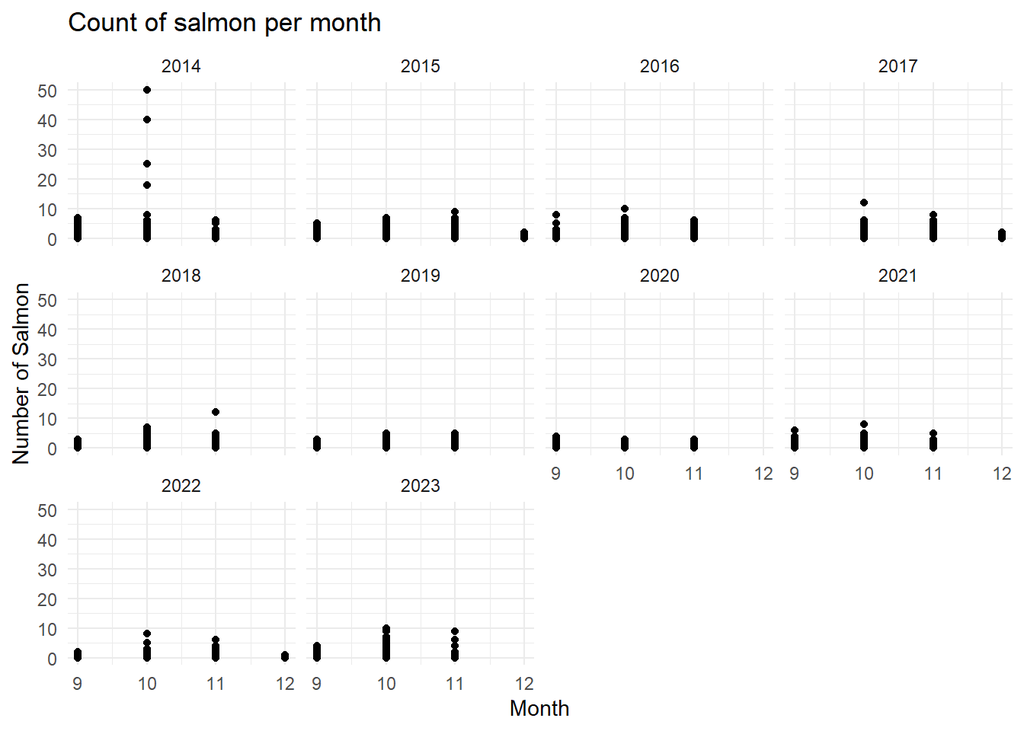

Since there are outliers, will remove and plot again

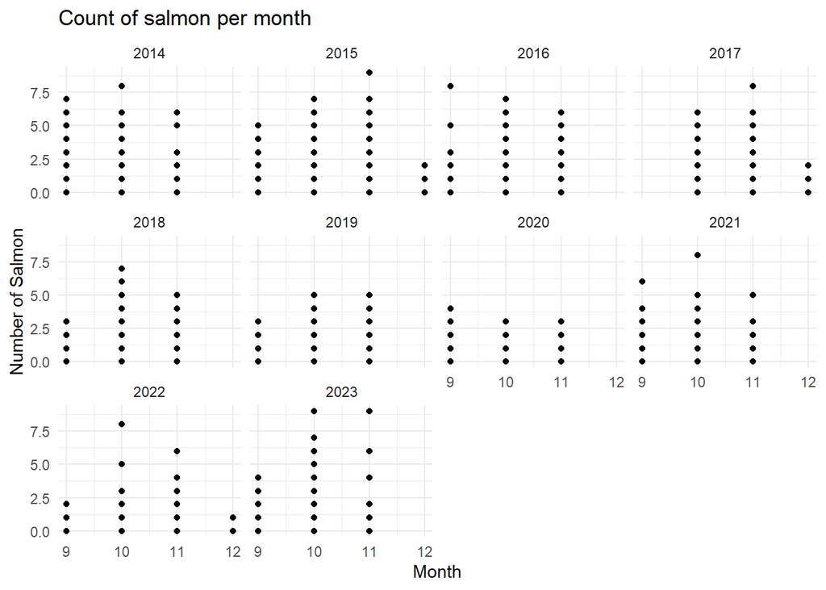

#### location

- Location clean up is needed. There are some names that appear less than 5 times. We could check if they correspond to another location name, and it is spelled differently

```
##
##                         aleck                  aleck riffle
##                            90                            32
##                       bedrock                bedrock riffle
##                           898                          1982
##           below big hole east        below lower auditorium
##                            59                           481
##                       big bar                big bar riffle
##                            33                            24
##                 big hole east                 big hole west
##                           274                            47
##                    big riffle                    cottonwood
##                           104                          1214
##                    developing             developing riffle
##                             4                             3
##                           eye              eye side channel
##                            42                           107
## g-95 east side channel bottom                 g-95 east top
##                             1                             1
##                     g-95 main g-95 west side channel bottom
##                             1                             1
##               g95 east bottom  g95 east side channel bottom
##                           137                            66
##     g95 east side channel top                  g95 east top
##                            34                           103
##                      g95 main                      g95 west
##                            67                            40
##               g95 west bottom         g95 west side channel
##                             1                            23
##                       gateway          gateway main channel
##                            42                            15
##          gateway side channel                         goose
##                             8                            22
##                  goose riffle                 great western
##                             7                             7
##                      hatchery                 hatchery pipe
##                          1594                           892
##               hatchery riffle         hatchery side channel
##                          2169                           136
##   hatchery side channel upper                     high flow
```

[output cut: 28 more lines]

```
##                          1607                          2313
##           upper big hole east              upper cottonwood
##                             2                           644
##                upper hatchery         upper hatchery riffle
##                           696                           909
##                    upper hour               upper hour east
##                            99                             2
##                 upper mathews                upper matthews
##                           134                            33
##               upper mcfarland                upper robinson
##                            38                           843
##                    vance east                    vance west
##                           169                            50
##                          weir                   weir riffle
##                           105                           168
```

```
##  [1] "moe's side channel"            "upper cottonwood"
##  [3] "cottonwood"                    "lower auditorium"
##  [5] "top of auditorium"             "upper hatchery riffle"
##  [7] "upper auditorium"              "mid auditorium"
##  [9] "hatchery riffle"               "developing riffle"
## [11] "upper mcfarland"               "big riffle"
## [13] "g95 east bottom"               "g95 main"
## [15] "big hole east"                 "vance east"
## [17] "below big hole east"           "upper hour east"
## [19] "upper hour"                    "mid hour"
## [21] "keister"                       "big bar"
## [23] "lower mcfarland"               "middle auditorium"
## [25] "upper hatchery"                "hatchery"
## [27] "hatchery side channel"         "table mountain"
## [29] "goose"                         "g95 west side channel"
```

[output cut: 27 more lines]

**Locations surveyed less than 5 times**

For locations that are being surveyed less than five times, we might want to verify if they belong to other location area names. Otherwise, these sites might not have enough data to reliably analyze over time.

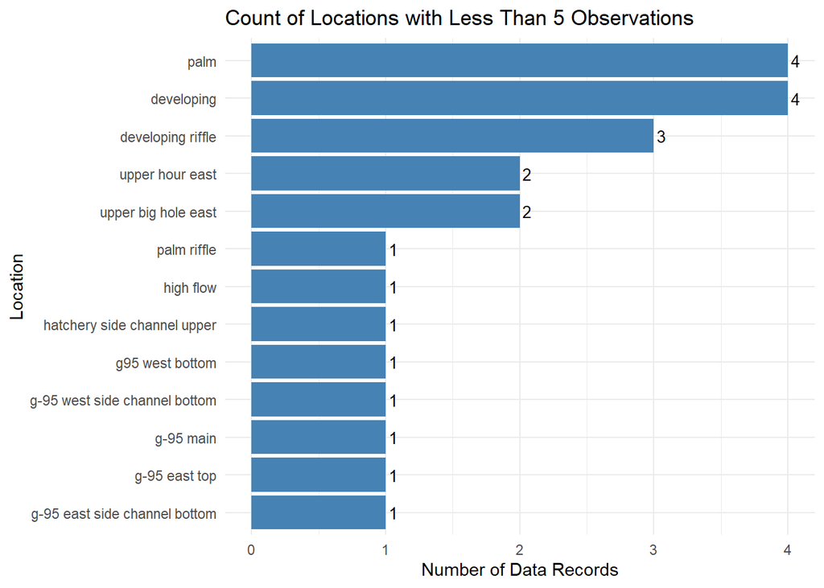

**Frequent locations and years surveyed**

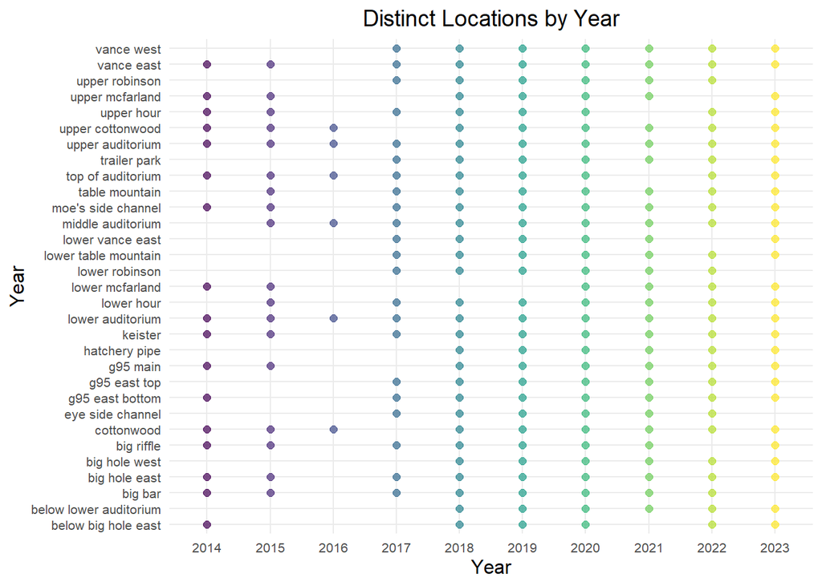

#### type

**Observations by type and date**

```
## [1] "p" "a" NA
```

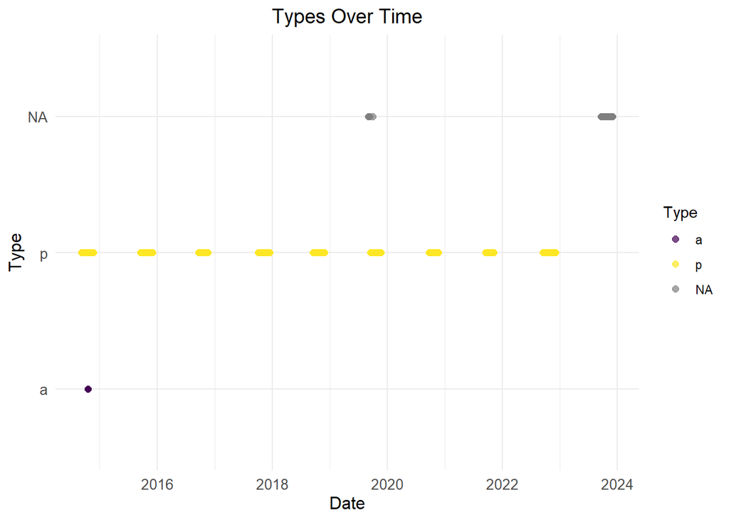

**Count of observations by type**

- note that all 2023 data does not have a `type` field
- based on conversations with the Feather River team we should remove the “a” observations and this field

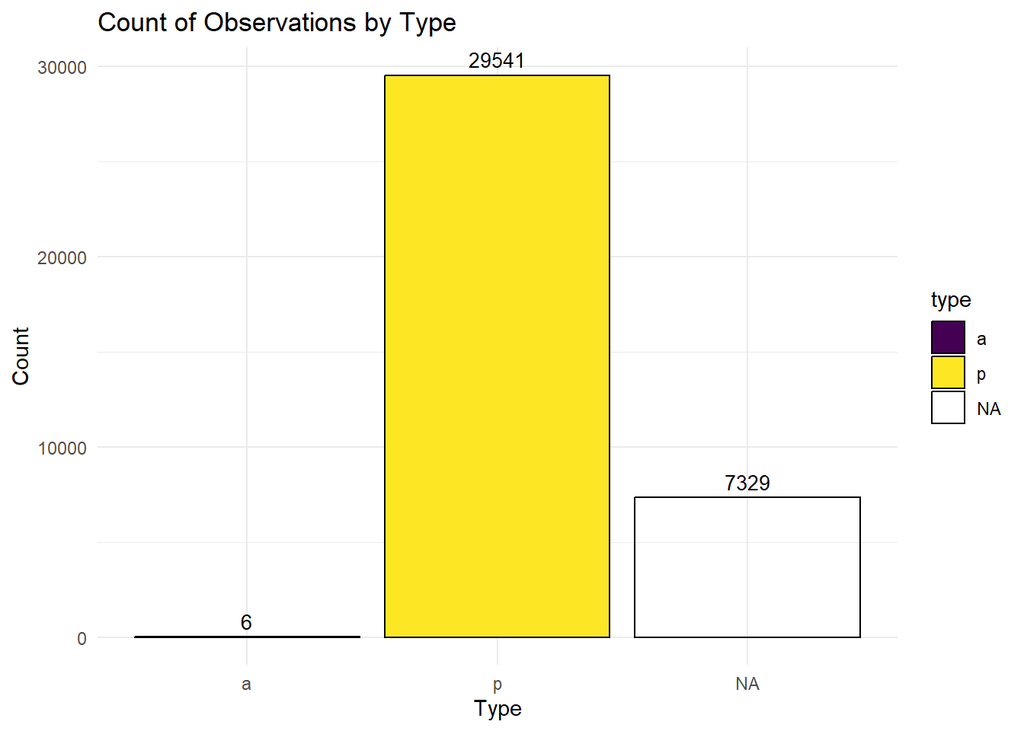

#### redd_count

**Redd counts by year**

```
## [1]  0 15
```

```
##    Min. 1st Qu.  Median    Mean 3rd Qu.    Max.
##   0.000   1.000   1.000   1.002   1.000  15.000
```

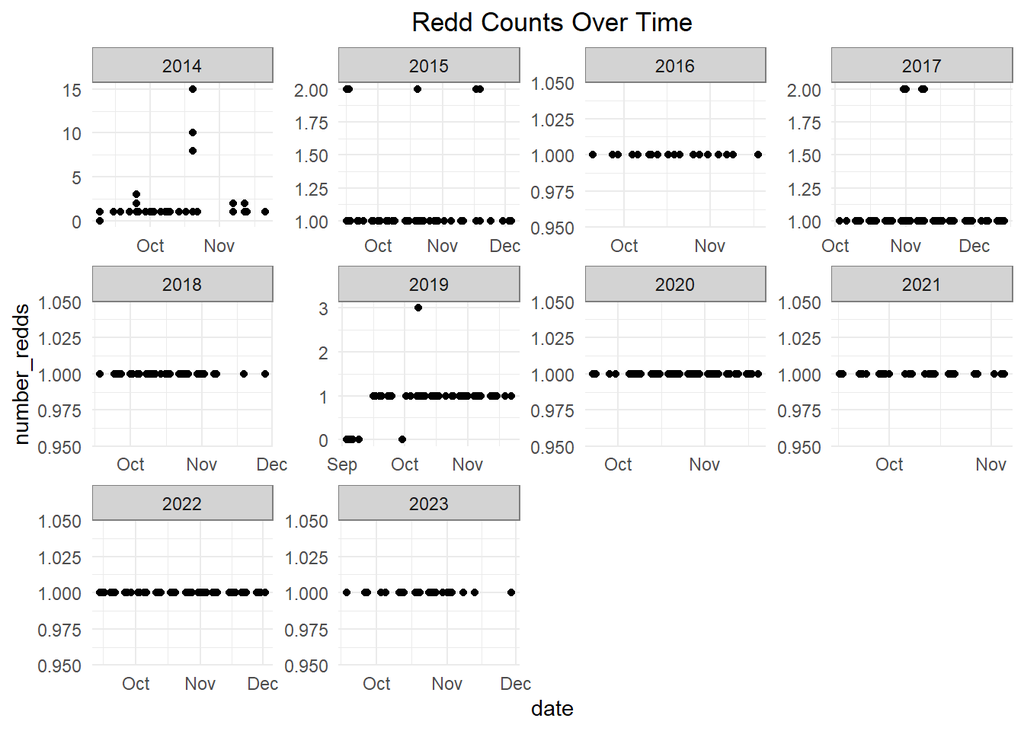

Same plot than above but with date values aggregated - using geom_col()

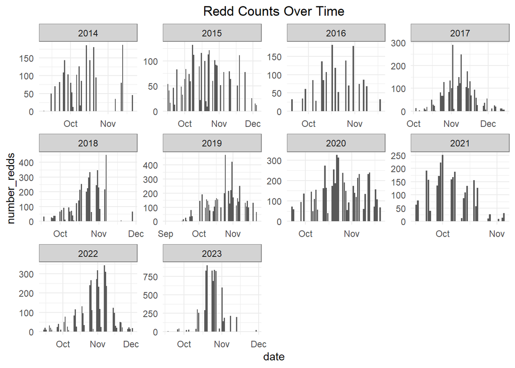

#### salmon_count

**Salmon counts by year**

- Noticed some outliers. Plotting below again removing values over 20

```
## [1]  0 50
```

```
##    Min. 1st Qu.  Median    Mean 3rd Qu.    Max.    NA's
##   0.000   0.000   0.000   0.297   0.000  50.000    6327
```

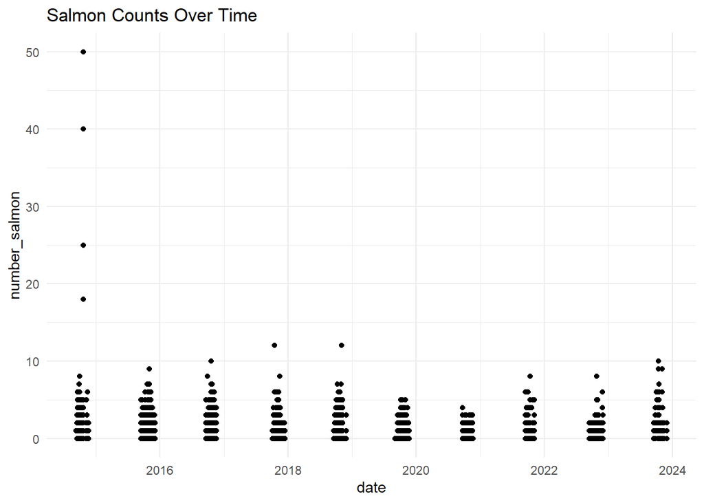

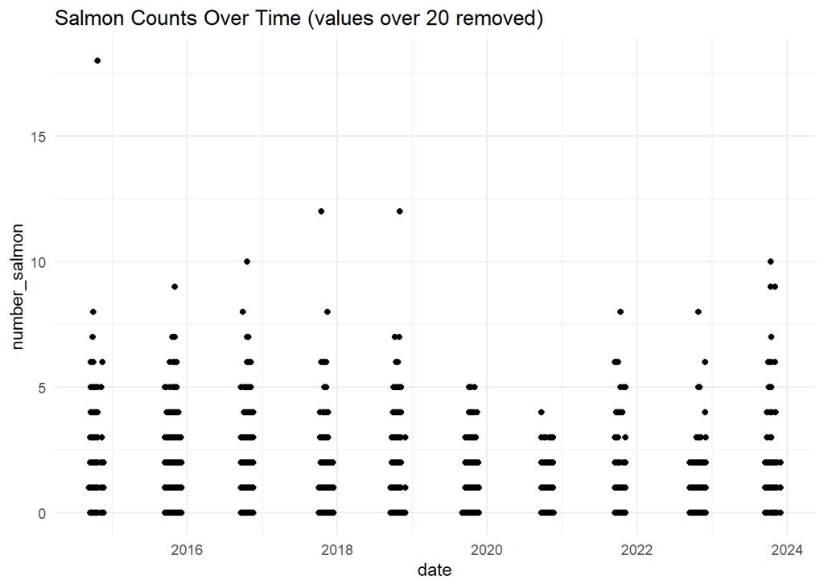

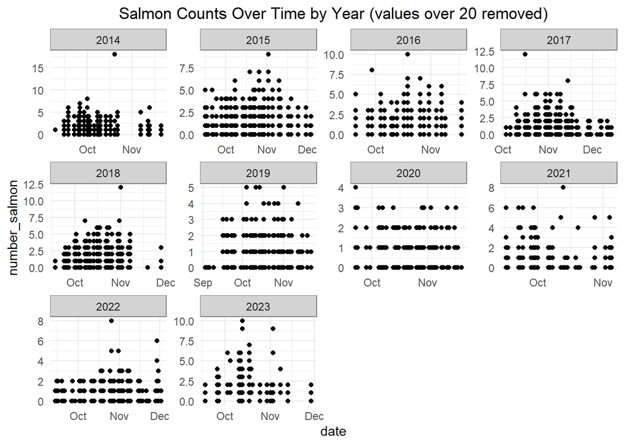

#### depth

```
## [1] 0.0 1.5
```

```
##    Min. 1st Qu.  Median    Mean 3rd Qu.    Max.    NA's
##    0.00    0.32    0.44    0.45    0.56    1.50   31807
```

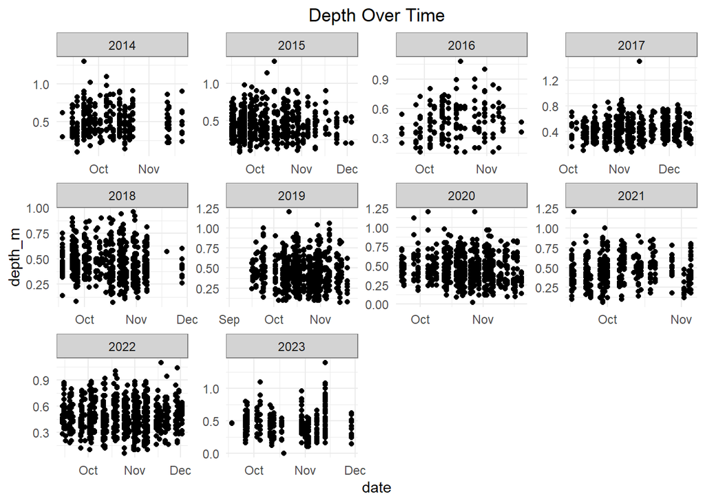

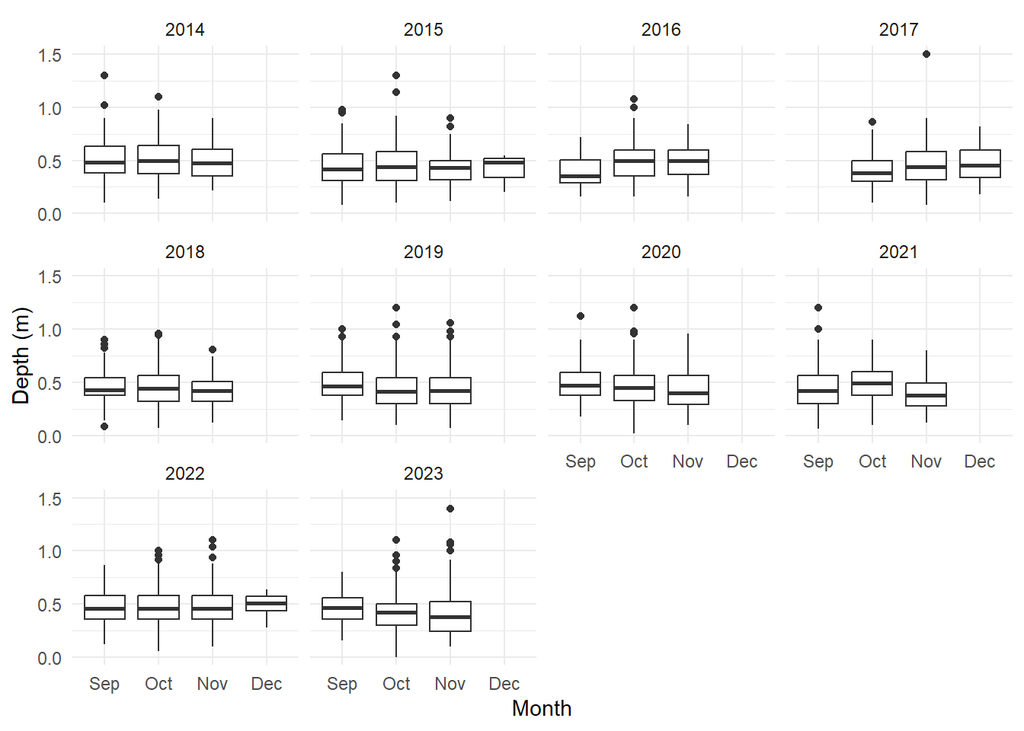

```
##    Min. 1st Qu.  Median    Mean 3rd Qu.    Max.    NA's
##    0.00    0.32    0.44    0.45    0.56    1.50   31807
```

#### velocity

```
## [1] -0.013  2.740
```

```
##    Min. 1st Qu.  Median    Mean 3rd Qu.    Max.    NA's
##   -0.01    0.33    0.48    0.52    0.66    2.74   32903
```

Turning that negative velocity to NA and plotting

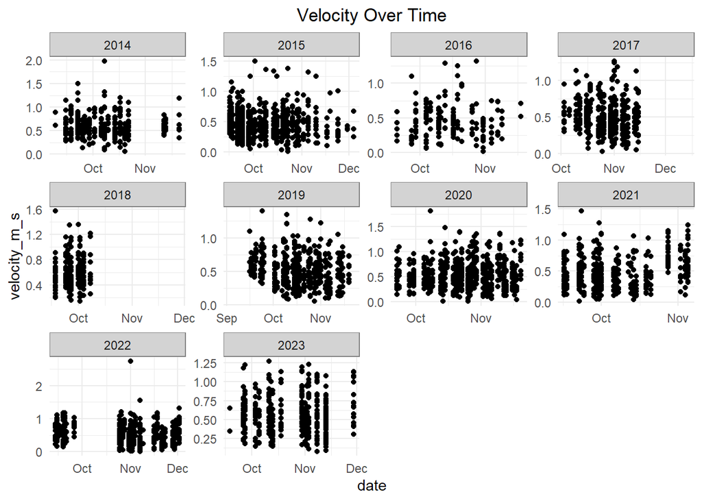

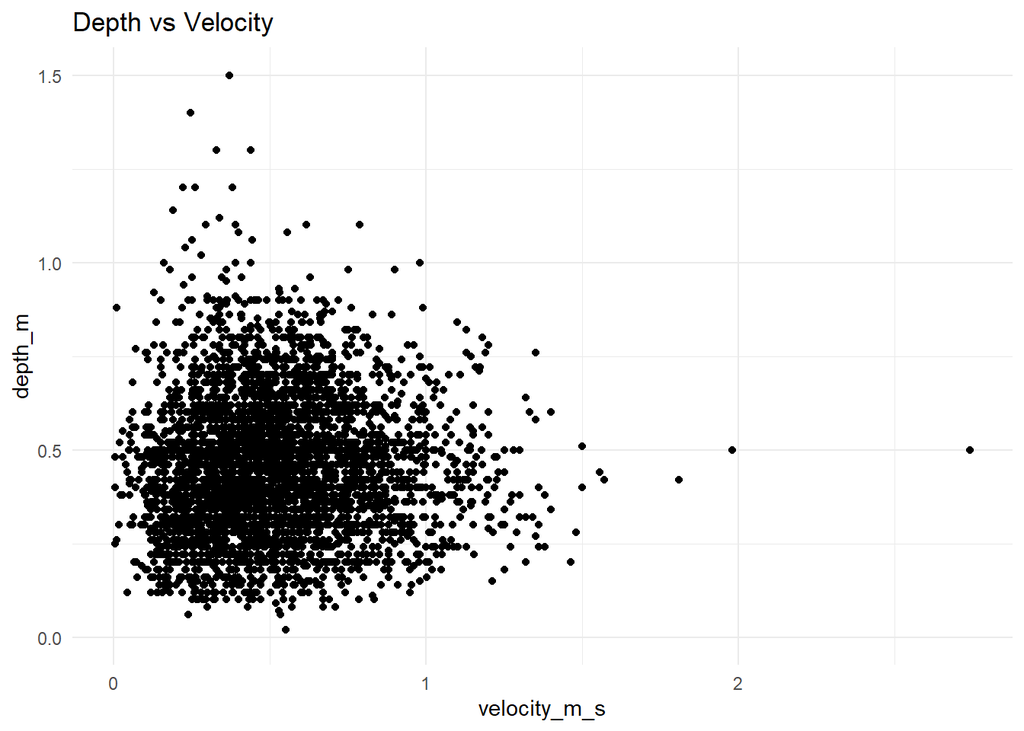

#### pot_depth_m

```
## [1] NA NA
```

```
##    Min. 1st Qu.  Median    Mean 3rd Qu.    Max.    NA's
##    0.00    0.42    0.51    0.55    0.63   50.00   32197
```

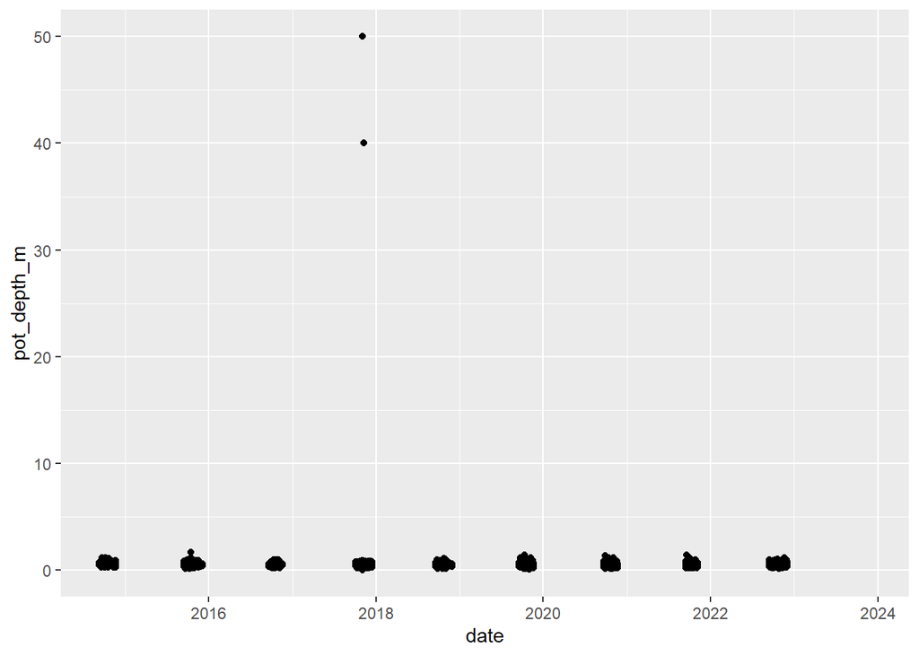

Same plot as above but outliers removed

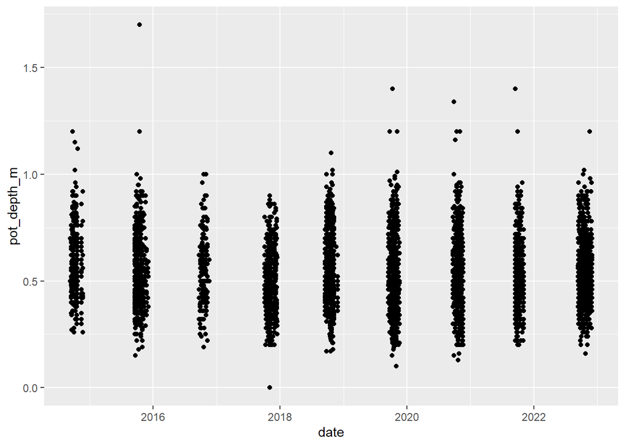

Turning values over 40 to NA

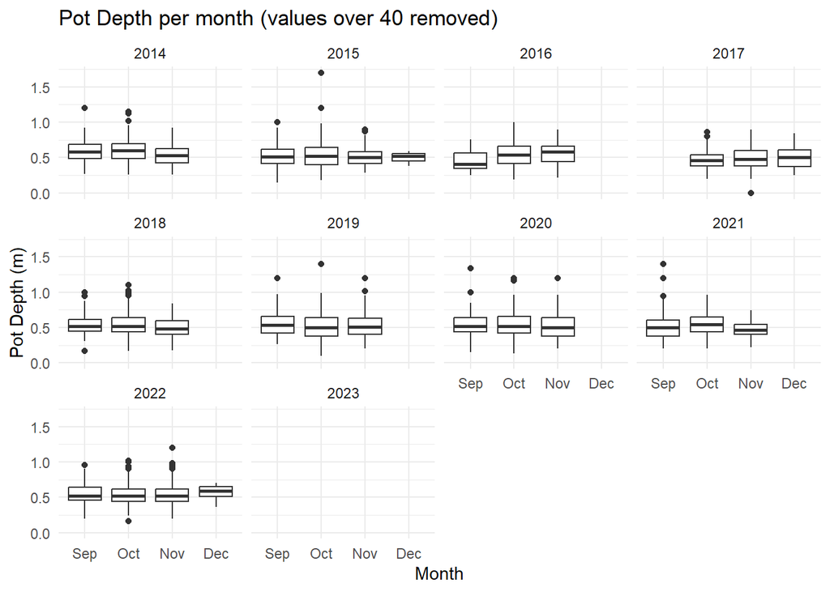

#### latitude/ longitude plot

Cleaning lat/long to plot on a map

[interactive chart not shown]

summary of depth

```
##    Min. 1st Qu.  Median    Mean 3rd Qu.    Max.    NA's
##    0.00    0.32    0.44    0.45    0.56    1.50   31807
```

summary of pot_depth after modifications

```
##    Min. 1st Qu.  Median    Mean 3rd Qu.    Max.    NA's
##    0.00    0.42    0.51    0.53    0.63    1.70   32199
```

summary of velocity_m_s after modifications

```
##    Min. 1st Qu.  Median    Mean 3rd Qu.    Max.    NA's
##    0.00    0.33    0.48    0.52    0.66    2.74   32904
```